# Practical Machine Learning Project

Karen Lowe

January 21, 2016

# Pre-Processing

The following code reads in the full data set and the 20 test cases, that I will call the validation data to differentiate it from the test data that I will create for testing the final model choice.

```r
library(caret)
```

```r
filenameTrain <-"/Users/Karen/Coursera/Machine Learning/pml-training.csv"
if (!file.exists(filenameTrain)) {
  fileUrl <- "https://d396qusza40orc.cloudfront.net/predmachlearn/pml-training.csv"
  dateDownloaded <- date()
  dateDownloaded
  download.file(fileUrl, destfile = filenameTrain, method = "curl")
}
filenameTest <-"/Users/Karen/Coursera/Machine Learning/pml-testing.csv"
if (!file.exists(filenameTest)) {
  fileUrl <- "https://d396qusza40orc.cloudfront.net/predmachlearn/pml-testing.csv"
  dateDownloaded <- date()
  dateDownloaded
  download.file(fileUrl, destfile = filenameTest, method = "curl")
}

pmldata <- read.csv(filenameTrain)
pmldatavalid <- read.csv(filenameTest)
```

I need to do a lot of data cleaning as there are a lot of NA values, even in the 20 validation cases. Unless I do imputation, there shouldn’t be any variables included to train the model for which we don’t have values in the validation data. Looking more carefully, it turns out that the same values that are NA for the validation data are also NA for any rows where `new_window=="no"`. On the other hand, where `new_window == "yes"`, these columns have values and the NAs occur where the `new_window=="no"` rows have values. This is because the rows where `new_window == "yes"` are summary rows with averaged values. As a result, I eliminated any columns in the training data that are NA in the validation data. Also, I eliminated the rows where `new_window == "yes"` in the trainig data. The same columns are eliminated from the validation data so that it retains the same shape as the training data. This is performed in the following code:

```r
good<-(1:ncol(pmldatavalid))[apply(pmldatavalid,2,function (x) sum(!is.na(x))==length(x))]
pmldata<-pmldata[pmldata$new_window=="no",good]
pmldatavalid<-pmldatavalid[,good]
dim(pmldata)
```

```
## [1] 19216    60
```

```r
dim(pmldatavalid)
```

```
## [1] 20 60
```

The following splits the training data using a 70/30 split for data to build the model and data to test the model.

```r
set.seed(2183)
inTrain <- createDataPartition(y=pmldata$classe,
                              p=0.7, list=FALSE)
training <- pmldata[inTrain,]
testing <- pmldata[-inTrain,]
```

# Exploratory Feature Selection

I looked at some plots of the 4x13 potential features that correspond to the sensor measurements. It’s impossible to look at all the interrelations between these, but I did produce pairs plots within logical groupings within each of the 4 sensors.

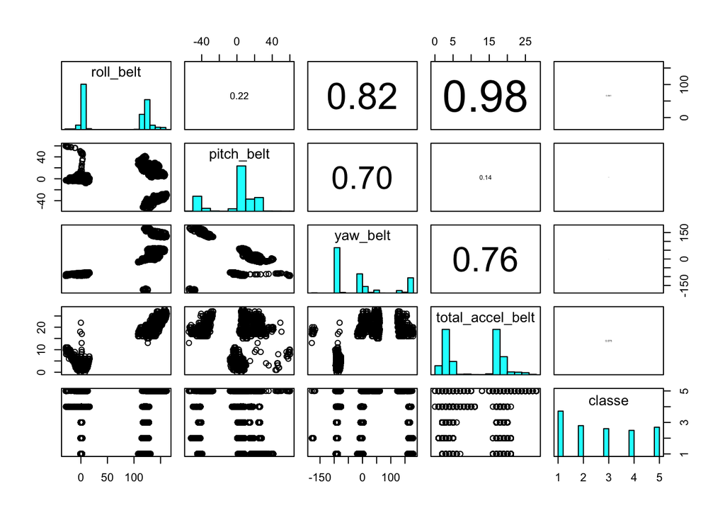

```r
# First let's look at pairwise within the first 4 variables measured on the belt. The following are copied from help(panel).
panel.hist <- function(x, ...)
{
    usr <- par("usr"); on.exit(par(usr))
    par(usr = c(usr[1:2], 0, 1.5) )
    h <- hist(x, plot = FALSE)
    breaks <- h$breaks; nB <- length(breaks)
    y <- h$counts; y <- y/max(y)
    rect(breaks[-nB], 0, breaks[-1], y, col = "cyan", ...)
}
panel.cor <- function(x, y, digits = 2, prefix = "", cex.cor, ...)
{
    usr <- par("usr"); on.exit(par(usr))
    par(usr = c(0, 1, 0, 1))
    r <- abs(cor(x, y))
    txt <- format(c(r, 0.123456789), digits = digits)[1]
    txt <- paste0(prefix, txt)
    if(missing(cex.cor)) cex.cor <- 0.8/strwidth(txt)
    text(0.5, 0.5, txt, cex = cex.cor * r)
}
pairs(training[,c(8:11,60)],upper.panel=panel.cor,diag.panel=panel.hist)
```

```r
# The following code produces plots for all of the other variables, however, I am only showing one as an example and have commented out the rest of the code.
#pairs(training[,c(12:14,60)],upper.panel=panel.cor,diag.panel=panel.hist)
#pairs(training[,c(15:17,60)],upper.panel=panel.cor,diag.panel=panel.hist)
#pairs(training[,c(18:20,60)],upper.panel=panel.cor,diag.panel=panel.hist)
#pairs(training[,c(13+8:11,60)],upper.panel=panel.cor,diag.panel=panel.hist)
#pairs(training[,c(13+12:14,60)],upper.panel=panel.cor,diag.panel=panel.hist)
#pairs(training[,c(13+15:17,60)],upper.panel=panel.cor,diag.panel=panel.hist)
#pairs(training[,c(13+18:20,60)],upper.panel=panel.cor,diag.panel=panel.hist)
#pairs(training[,c(26+8:11,60)],upper.panel=panel.cor,diag.panel=panel.hist)
#pairs(training[,c(26+12:14,60)],upper.panel=panel.cor,diag.panel=panel.hist)
#pairs(training[,c(26+15:17,60)],upper.panel=panel.cor,diag.panel=panel.hist)
#pairs(training[,c(26+18:20,60)],upper.panel=panel.cor,diag.panel=panel.hist)
#pairs(training[,c(39+8:11,60)],upper.panel=panel.cor,diag.panel=panel.hist)
#pairs(training[,c(39+12:14,60)],upper.panel=panel.cor,diag.panel=panel.hist)
#pairs(training[,c(39+15:17,60)],upper.panel=panel.cor,diag.panel=panel.hist)
#pairs(training[,c(39+18:20,60)],upper.panel=panel.cor,diag.panel=panel.hist)
```

After looking at all of these plots, I drew the following conclusions:

- The distribution of many of these measurement values are bimodal, which will not work well for a linear regression model.
- Some of these measurements are very correlated–such as a .98 correlation between `roll_belt` and `total_accel_belt`. This is not a problem for recursive partitioning since the algorithm would likely choose one of the variables or the other, but both could not be used in a linear regression model.
- You can definitely see some differences between the activities and some of these variables. For example, for `roll_belt`, the largest and smallest values are recorded when doing activity E.
- There are also many interesting interrelationships between these variables as evidenced by the clumping patterns shown.

# Preliminary Models

I decided to start with a simple Rpart model using all of the measurement variables. I do not think it makes sense to use the timestamp information or the window variables.

```r
library(partykit)
modFit<-train(classe~.,method="rpart",data=training[,-c(1:7)])
confusionMatrix(predict(modFit$final,training[,-c(1:7)],type="class"),training$classe)$overall
```

```
##       Accuracy          Kappa  AccuracyLower  AccuracyUpper   AccuracyNull
##      0.4978072      0.3435780      0.4893223      0.5062930      0.2846949
## AccuracyPValue  McnemarPValue
##      0.0000000            NaN
```

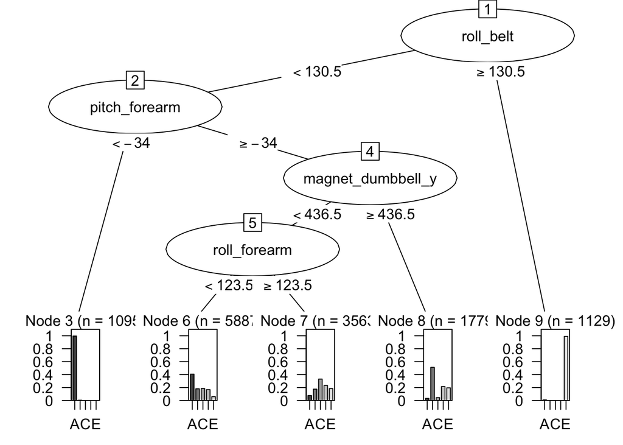

```r
mod<-as.party(modFit$final)
plot(mod)
```

```r
#Adelmo
onePerson<-training[training$user_name=="adelmo",-(1:7)]
modFit<-train(classe~.,method="rpart",data=onePerson)
confusionMatrix(predict(modFit$final,onePerson,type="class"),onePerson$classe)$overall
```

```
##       Accuracy          Kappa  AccuracyLower  AccuracyUpper   AccuracyNull
##      0.6991051      0.6169585      0.6813503      0.7164244      0.3016406
## AccuracyPValue  McnemarPValue
##      0.0000000            NaN
```

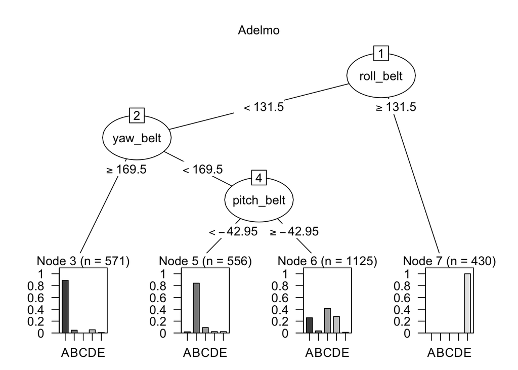

```r
mod<-as.party(modFit$final)
plot(mod,main="Adelmo")
```

```r
#Carlitos
onePerson<-training[training$user_name=="carlitos",-(1:7)]
modFit<-train(classe~.,method="rpart",data=onePerson)
confusionMatrix(predict(modFit$final,onePerson,type="class"),onePerson$classe)$overall
```

```
##       Accuracy          Kappa  AccuracyLower  AccuracyUpper   AccuracyNull
##   6.537575e-01   5.596628e-01   6.333072e-01   6.737914e-01   2.752420e-01
## AccuracyPValue  McnemarPValue
##  3.448977e-294            NaN
```

```r
#mod<-as.party(modFit$final)
#plot(mod,main="Carlitos")
#Charles
onePerson<-training[training$user_name=="charles",-(1:7)]
modFit<-train(classe~.,method="rpart",data=onePerson)
confusionMatrix(predict(modFit$final,onePerson,type="class"),onePerson$classe)$overall
```

```
##       Accuracy          Kappa  AccuracyLower  AccuracyUpper   AccuracyNull
##      0.6339733      0.5288474      0.6143217      0.6532967      0.2537563
## AccuracyPValue  McnemarPValue
##      0.0000000            NaN
```

```r
#mod<-as.party(modFit$final)
#plot(mod,main="Charles")
#Eurico
onePerson<-training[training$user_name=="eurico",-(1:7)]
modFit<-train(classe~.,method="rpart",data=onePerson)
confusionMatrix(predict(modFit$final,onePerson,type="class"),onePerson$classe)$overall
```

```
##       Accuracy          Kappa  AccuracyLower  AccuracyUpper   AccuracyNull
##   8.030666e-01   7.526061e-01   7.853447e-01   8.199330e-01   2.764734e-01
## AccuracyPValue  McnemarPValue
##   0.000000e+00   1.074267e-32
```

```r
#mod<-as.party(modFit$final)
#plot(mod,main="Eurico")
#Jeremy
onePerson<-training[training$user_name=="jeremy",-(1:7)]
modFit<-train(classe~.,method="rpart",data=onePerson)
confusionMatrix(predict(modFit$final,onePerson,type="class"),onePerson$classe)$overall
```

```
##       Accuracy          Kappa  AccuracyLower  AccuracyUpper   AccuracyNull
##   6.087893e-01   4.847786e-01   5.885927e-01   6.287109e-01   3.446790e-01
## AccuracyPValue  McnemarPValue
##  5.688689e-148            NaN
```

```r
#mod<-as.party(modFit$final)
#plot(mod,main="Jeremy")
```

# Final Model Selection: Random Forests within each of 6 users

The following is the code that produces these models. However, given the long running time, I saved these models and will reload them here as I create the html file. So this code is not executed.

```r
library(randomForest)
onePerson<-training[training$user_name=="adelmo",-(1:7)]
#adelmoFit<-train(classe~.,method="rf",data=onePerson,prox=TRUE)
#save(adelmoFit,file="adelmoFit.Rdata")
load("/Users/Karen/adelmoFit.Rdata")
confusionMatrix(predict(adelmoFit$final,onePerson,type="class"),onePerson$classe)$overall
```

```
##       Accuracy          Kappa  AccuracyLower  AccuracyUpper   AccuracyNull
##      0.9977629      0.9971476      0.9951371      0.9991786      0.3016406
## AccuracyPValue  McnemarPValue
##      0.0000000            NaN
```

```r
onePerson<-training[training$user_name=="carlitos",-(1:7)]
#carlitosFit<-train(classe~.,method="rf",data=onePerson,prox=TRUE)
#save(carlitosFit,file="carlitosFit.Rdata")
load("/Users/Karen/carlitosFit.Rdata")
confusionMatrix(predict(carlitosFit$final,onePerson,type="class"),onePerson$classe)$overall
```

```
##       Accuracy          Kappa  AccuracyLower  AccuracyUpper   AccuracyNull
##      0.9986169      0.9982488      0.9959633      0.9997147      0.2752420
## AccuracyPValue  McnemarPValue
##      0.0000000            NaN
```

```r
onePerson<-training[training$user_name=="charles",-(1:7)]
#charlesFit<-train(classe~.,method="rf",data=onePerson,prox=TRUE)
#save(charlesFit,file="charlesFit.Rdata")
load("/Users/Karen/charlesFit.Rdata")
confusionMatrix(predict(charlesFit$final,onePerson,type="class"),onePerson$classe)$overall
```

```
##       Accuracy          Kappa  AccuracyLower  AccuracyUpper   AccuracyNull
##      0.9979132      0.9973718      0.9951369      0.9993221      0.2537563
## AccuracyPValue  McnemarPValue
##      0.0000000            NaN
```

```r
onePerson<-training[training$user_name=="eurico",-(1:7)]
#euricoFit<-train(classe~.,method="rf",data=onePerson,prox=TRUE)
#save(euricoFit,file="euriocFit.Rdata")
load("/Users/Karen/euriocFit.Rdata")
confusionMatrix(predict(euricoFit$final,onePerson,type="class"),onePerson$classe)$overall
```

```
##       Accuracy          Kappa  AccuracyLower  AccuracyUpper   AccuracyNull
##      0.9990417      0.9987904      0.9965426      0.9998839      0.2764734
## AccuracyPValue  McnemarPValue
##      0.0000000            NaN
```

```r
onePerson<-training[training$user_name=="jeremy",-(1:7)]
#jeremyFit<-train(classe~.,method="rf",data=onePerson,prox=TRUE)
#save(jeremyFit,file="jeremyFit.Rdata")
load("/Users/Karen/jeremyFit.Rdata")
confusionMatrix(predict(jeremyFit$final,onePerson,type="class"),onePerson$classe)$overall
```

```
##       Accuracy          Kappa  AccuracyLower  AccuracyUpper   AccuracyNull
##      0.9987075      0.9983260      0.9962273      0.9997334      0.3446790
## AccuracyPValue  McnemarPValue
##      0.0000000            NaN
```

```r
onePerson<-training[training$user_name=="pedro",-(1:7)]
#pedroFit<-train(classe~.,method="rf",data=onePerson,prox=TRUE)
#save(pedroFit,file="pedroFit.Rdata")
load("/Users/Karen/pedroFit.Rdata")
confusionMatrix(predict(pedroFit$final,onePerson,type="class"),onePerson$classe)$overall
```

```
##       Accuracy          Kappa  AccuracyLower  AccuracyUpper   AccuracyNull
##      0.9972191      0.9965128      0.9935224      0.9990965      0.2441602
## AccuracyPValue  McnemarPValue
##      0.0000000            NaN
```

# The estimate of out of sample error

```r
predictions<-data.frame(X = 1:nrow(testing),prediction=factor(x = rep("A",nrow(testing)), levels=c("A","B","C","D","E")))
onePersonTest<-testing[testing$user_name=="adelmo",-(1:7)]
predictions[testing$user_name=="adelmo",2]<-predict(adelmoFit$final,onePersonTest,type="class")

onePersonTest<-testing[testing$user_name=="carlitos",-(1:7)]
predictions[testing$user_name=="carlitos",2]<-predict(carlitosFit$final,onePersonTest,type="class")

onePersonTest<-testing[testing$user_name=="charles",-(1:7)]
predictions[testing$user_name=="charles",2]<-predict(charlesFit$final,onePersonTest,type="class")

onePersonTest<-testing[testing$user_name=="eurico",-(1:7)]
predictions[testing$user_name=="eurico",2]<-predict(euricoFit$final,onePersonTest,type="class")

onePersonTest<-testing[testing$user_name=="jeremy",-(1:7)]
predictions[testing$user_name=="jeremy",2]<-predict(jeremyFit$final,onePersonTest,type="class")

onePersonTest<-testing[testing$user_name=="pedro",-(1:7)]
predictions[testing$user_name=="pedro",2]<-predict(pedroFit$final,onePersonTest,type="class")

confusionMatrix(predictions$prediction,testing$class)$overall
```

```
##       Accuracy          Kappa  AccuracyLower  AccuracyUpper   AccuracyNull
##      0.9970501      0.9962681      0.9952812      0.9982807      0.2847475
## AccuracyPValue  McnemarPValue
##      0.0000000            NaN
```

# Prediction on 20 “test” cases.

Now to test on the test cases that I’m calling the validation data. I commented out the printing of predictions for this report because I wasn’t sure if this would be tantamount to printing the quiz answers. This model received a 20/20 on the quiz.

```r
adelmovalid<-pmldatavalid[pmldatavalid$user_name=="adelmo",-(1:7)]
carlitosvalid<-pmldatavalid[pmldatavalid$user_name=="carlitos",-(1:7)]
charlesvalid<-pmldatavalid[pmldatavalid$user_name=="charles",-(1:7)]
euricovalid<-pmldatavalid[pmldatavalid$user_name=="eurico",-(1:7)]
jeremyvalid<-pmldatavalid[pmldatavalid$user_name=="jeremy",-(1:7)]
pedrovalid<-pmldatavalid[pmldatavalid$user_name=="pedro",-(1:7)]

predictions<-data.frame(id=1:20,prediction=as.factor(c("A","B","C","D","E")))
predictions[adelmovalid$problem_id,2]<-predict(adelmoFit$final,adelmovalid,type="class")
predictions[carlitosvalid$problem_id,2]<-predict(carlitosFit$final,carlitosvalid,type="class")
predictions[charlesvalid$problem_id,2]<-predict(charlesFit$final,charlesvalid,type="class")
predictions[euricovalid$problem_id,2]<-predict(euricoFit$final,euricovalid,type="class")
predictions[jeremyvalid$problem_id,2]<-predict(jeremyFit$final,jeremyvalid,type="class")
predictions[pedrovalid$problem_id,2]<-predict(pedroFit$final,pedrovalid,type="class")
#predictions
```